# sales data EDA

```r
library(tidyverse)
library(readxl)
library(reshape2)
library(ggplot2)
library(maps)
```

# Read, process data

```r
# load raw data sheet
sales <- read_excel("2017 Sales Summary.xlsx",
                    sheet = "Raw Data From Adroit")

# web sales data sheet
web <- read_excel("2017 Sales Summary.xlsx",
                  sheet = "STM Web Sales Summary",
                  col_names = F)
```

View before doing anything to raw sales data

```r
glimpse(sales)
```

```
## Observations: 1,338
## Variables: 22
## $ Agent           <chr> "America's Health Advisors Insurance Agency - ...
## $ ID              <dbl> 672170522, 672170491, NA, 672170006, 672169745...
## $ Policy          <chr> "STA10045799", "STA10037359", NA, "STA10027830...
## $ Name            <chr> " Michael  Arcuri  ", " Kallie  Cole  ", NA, "...
## $ City            <chr> "exton", "Surprise", NA, "Loretto", "prescott"...
## $ State           <chr> "PA", "AZ", NA, "PA", "AZ", "AZ", "AZ", "KY", ...
## $ Phone           <chr> "(610) 563-4264", "(602) 615-2430", NA, "(814)...
## $ Email           <chr> "michael.arcuri@comcast.net", "kcranch55@yahoo...
## $ Product         <chr> "Pivot Deluxe 3x4", "Pivot Economy 3x4 ", NA, ...
## $ Benefit         <chr> "$2,500 Deductible", "$3,000 Deductible", NA, ...
## $ One-time        <dbl> 15, 15, NA, 15, 15, 15, 15, 15, 15, 15, 15, 15...
## $ Monthly         <dbl> 594.48, 165.18, NA, 266.72, 400.11, 129.50, 80...
## $ Method          <chr> "MasterCard", "ACH", NA, "ACH", "Visa", "ACH",...
## $ Paid            <dbl> 1, NA, NA, 1, 1, 1, 1, 1, NA, NA, 1, 1, 1, NA,...
## $ Created         <dttm> 2017-07-01, 2017-07-01, NA, 2017-06-30, 2017-...
## $ First Billing   <dttm> 2017-07-01, 2017-07-04, NA, 2017-06-30, 2017-...
## $ Active          <dttm> 2017-08-01, 2017-07-04, NA, 2017-07-01, 2017-...
## $ Next Billing    <dttm> 2017-09-01, NA, NA, 2017-08-01, 2017-08-01, 2...
## $ Amount          <dbl> 623.48, 209.18, NA, 295.72, 429.11, 158.50, 10...
## $ Hold            <chr> NA, NA, NA, NA, NA, NA, NA, NA, NA, NA, NA, NA...
## $ Date Inactive   <dttm> NA, NA, NA, NA, NA, NA, NA, NA, NA, NA, NA, N...
## $ Inactive Reason <chr> NA, NA, NA, NA, NA, NA, NA, NA, NA, NA, NA, NA...
```

```r
# filter data to remove completely NA rows
sales <- sales[rowSums(is.na(sales)) != ncol(sales),]
```

### Web data needs reformatting to be a dataframe

```r
web[is.na(web)] <- 0
names(web) <- web[2,] %>% unlist
names(web)[names(web)=="0"] <- unlist(web[1,])[names(web)=="0"]

web <- web[-(1:2),]
```

Date column needs to be cleaned up

```r
web$Date <- as.numeric(web$Date)
web <- web[!is.na(web$Date),]

web$Date <- as.Date(web$Date,
                    origin = "1899-12-30")
```

### Website-specific dataframe creation

```r
website <- web[names(web)[c(1, 63:70)]]

change <- names(website)[-1]
for(x in seq_along(change)){
  website[[change[x]]] <- as.numeric(website[[change[x]]])}
names(website)[names(website)=="TOTAL"] <- "Total Web Sales"
website <- website %>% filter(Date < "2017-07-03")
glimpse(website)
```

```
## Observations: 183
## Variables: 9
## $ Date                 <date> 2017-01-01, 2017-01-02, 2017-01-03, 2017...
## $ Total Web Sales      <dbl> 2, 4, 3, 1, 1, 2, 0, 0, 0, 0, 2, 1, 5, 1,...
## $ Sessions             <dbl> 117, 202, 272, 231, 243, 189, 131, 128, 2...
## $ Users                <dbl> 106, 178, 233, 201, 216, 156, 123, 118, 1...
## $ Pageviews            <dbl> 461, 785, 894, 767, 809, 732, 373, 331, 8...
## $ Pages/ Session       <dbl> 3.94, 3.89, 3.29, 3.32, 3.33, 3.87, 2.85,...
## $ Avg Session Duration <dbl> 0.12083333, 0.13333333, 0.10833333, 0.115...
## $ Bounce Rate          <dbl> 0.3333, 0.4554, 0.4779, 0.4589, 0.4691, 0...
## $ % of New Session     <dbl> 0.7436, 0.6733, 0.6949, 0.6970, 0.7119, 0...
```

## Add columns and features to raw data

### Dates

Add columns for other intervals of each date

```r
sales$month_created <- as.Date(cut(sales$Created,
  breaks = "month"))

sales$week_created <- as.Date(cut(sales$Created,
  breaks = "week"))

sales$month_active <- as.Date(cut(sales$Active,
  breaks = "month"))
```

### Count column for aggregation

for ggplot2

```r
sales$Count <- rep(1, nrow(sales))
```

### Mapping state names for plotting purposes

ggplot2 requires the long form name of a state but this dataset only has state acronyms. I’m merging the data to **state.csv** in order to make graphs later

```r
state_mapping <- read_csv("states.csv")
names(state_mapping) <- c("region","State") # for merge
state_mapping$region <- tolower(state_mapping$region) #for merge
head(state_mapping)
```

```
## # A tibble: 6 × 2
##       region State
##        <chr> <chr>
## 1    alabama    AL
## 2     alaska    AK
## 3    arizona    AZ
## 4   arkansas    AR
## 5 california    CA
## 6   colorado    CO
```

The state data is latitute and longitude information for states - meta data needed for plots

```r
state_data <- ggplot2::map_data("state")
glimpse(state_data)
```

```
## Observations: 15,537
## Variables: 6
## $ long      <dbl> -87.46201, -87.48493, -87.52503, -87.53076, -87.5708...
## $ lat       <dbl> 30.38968, 30.37249, 30.37249, 30.33239, 30.32665, 30...
## $ group     <dbl> 1, 1, 1, 1, 1, 1, 1, 1, 1, 1, 1, 1, 1, 1, 1, 1, 1, 1...
## $ order     <int> 1, 2, 3, 4, 5, 6, 7, 8, 9, 10, 11, 12, 13, 14, 15, 1...
## $ region    <chr> "alabama", "alabama", "alabama", "alabama", "alabama...
## $ subregion <chr> NA, NA, NA, NA, NA, NA, NA, NA, NA, NA, NA, NA, NA, ...
```

##### **Merge**

```r
state_mapping <- left_join(state_data, state_mapping,  by = "region")
glimpse(state_mapping)
```

```
## Observations: 15,537
## Variables: 7
## $ long      <dbl> -87.46201, -87.48493, -87.52503, -87.53076, -87.5708...
## $ lat       <dbl> 30.38968, 30.37249, 30.37249, 30.33239, 30.32665, 30...
## $ group     <dbl> 1, 1, 1, 1, 1, 1, 1, 1, 1, 1, 1, 1, 1, 1, 1, 1, 1, 1...
## $ order     <int> 1, 2, 3, 4, 5, 6, 7, 8, 9, 10, 11, 12, 13, 14, 15, 1...
## $ region    <chr> "alabama", "alabama", "alabama", "alabama", "alabama...
## $ subregion <chr> NA, NA, NA, NA, NA, NA, NA, NA, NA, NA, NA, NA, NA, ...
## $ State     <chr> "AL", "AL", "AL", "AL", "AL", "AL", "AL", "AL", "AL"...
```

```r
state_sales <- merge(sales, state_mapping, sort=F)
```

```r
glimpse(sales)
```

```
## Observations: 1,336
## Variables: 26
## $ Agent           <chr> "America's Health Advisors Insurance Agency - ...
## $ ID              <dbl> 672170522, 672170491, 672170006, 672169745, 67...
## $ Policy          <chr> "STA10045799", "STA10037359", "STA10027830", "...
## $ Name            <chr> " Michael  Arcuri  ", " Kallie  Cole  ", " Jan...
## $ City            <chr> "exton", "Surprise", "Loretto", "prescott", "L...
## $ State           <chr> "PA", "AZ", "PA", "AZ", "AZ", "AZ", "KY", "GA"...
## $ Phone           <chr> "(610) 563-4264", "(602) 615-2430", "(814) 674...
## $ Email           <chr> "michael.arcuri@comcast.net", "kcranch55@yahoo...
## $ Product         <chr> "Pivot Deluxe 3x4", "Pivot Economy 3x4 ", "Piv...
## $ Benefit         <chr> "$2,500 Deductible", "$3,000 Deductible", "$5,...
## $ One-time        <dbl> 15, 15, 15, 15, 15, 15, 15, 15, 15, 15, 15, 15...
## $ Monthly         <dbl> 594.48, 165.18, 266.72, 400.11, 129.50, 80.47,...
## $ Method          <chr> "MasterCard", "ACH", "ACH", "Visa", "ACH", "Vi...
## $ Paid            <dbl> 1, NA, 1, 1, 1, 1, 1, NA, NA, 1, 1, 1, NA, 1, ...
## $ Created         <dttm> 2017-07-01, 2017-07-01, 2017-06-30, 2017-06-3...
## $ First Billing   <dttm> 2017-07-01, 2017-07-04, 2017-06-30, 2017-06-3...
## $ Active          <dttm> 2017-08-01, 2017-07-04, 2017-07-01, 2017-07-0...
## $ Next Billing    <dttm> 2017-09-01, NA, 2017-08-01, 2017-08-01, 2017-...
## $ Amount          <dbl> 623.48, 209.18, 295.72, 429.11, 158.50, 109.47...
## $ Hold            <chr> NA, NA, NA, NA, NA, NA, NA, NA, NA, NA, NA, NA...
## $ Date Inactive   <dttm> NA, NA, NA, NA, NA, NA, NA, NA, NA, NA, NA, N...
## $ Inactive Reason <chr> NA, NA, NA, NA, NA, NA, NA, NA, NA, NA, NA, NA...
## $ month_created   <date> 2017-07-01, 2017-07-01, 2017-06-01, 2017-06-0...
## $ week_created    <date> 2017-06-26, 2017-06-26, 2017-06-26, 2017-06-2...
## $ month_active    <date> 2017-08-01, 2017-07-01, 2017-07-01, 2017-07-0...
## $ Count           <dbl> 1, 1, 1, 1, 1, 1, 1, 1, 1, 1, 1, 1, 1, 1, 1, 1...
```

# Exploration

### Missing values

**Percentage of values missing from each column**

```r
map_dbl(sales, function(x) sum(is.na(x))/nrow(sales)) %>% sort
```

```
##           Agent              ID          Policy            Name
##     0.000000000     0.000000000     0.000000000     0.000000000
##            City           State         Product         Created
##     0.000000000     0.000000000     0.000000000     0.000000000
##   month_created    week_created           Count           Phone
##     0.000000000     0.000000000     0.000000000     0.000748503
##           Email         Benefit         Monthly          Amount
##     0.001497006     0.002994012     0.002994012     0.002994012
##        One-time          Method          Active    month_active
##     0.007485030     0.015718563     0.055389222     0.055389222
##   First Billing            Paid    Next Billing   Date Inactive
##     0.089820359     0.163922156     0.412425150     0.684880240
## Inactive Reason            Hold
##     0.711826347     0.948353293
```

### Unique values

**Number of unique values in each column**

```r
map_dbl(sales, function(x) length(unique(x))) %>% sort
```

```
##           Count        One-time          Method         Product
##               1               2               7               8
##   month_created         Benefit            Paid    month_active
##               8               9              10              10
## Inactive Reason           State    week_created            Hold
##              20              26              29              42
##    Next Billing           Agent   Date Inactive         Created
##              67              72             153             159
##          Active   First Billing            City         Monthly
##             174             183             929            1214
##          Amount           Email           Phone            Name
##            1249            1258            1262            1294
##              ID          Policy
##            1326            1336
```

## **Graphs**

### Distribution of sales Amount ($ shown for each sale/account)

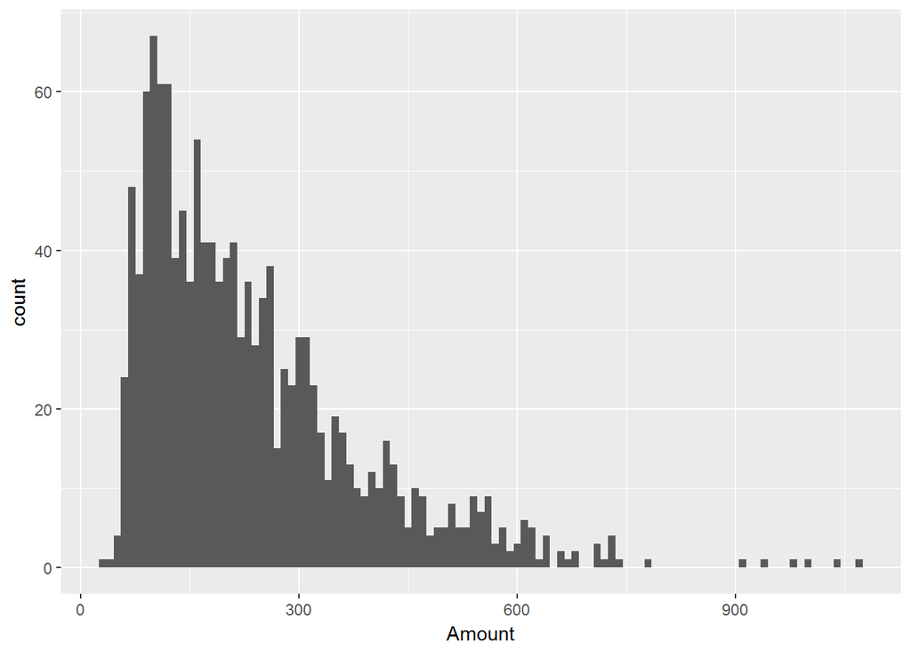

```r
ggplot(sales, aes(Amount)) + geom_histogram(binwidth=10)
```

### Number of sales by product

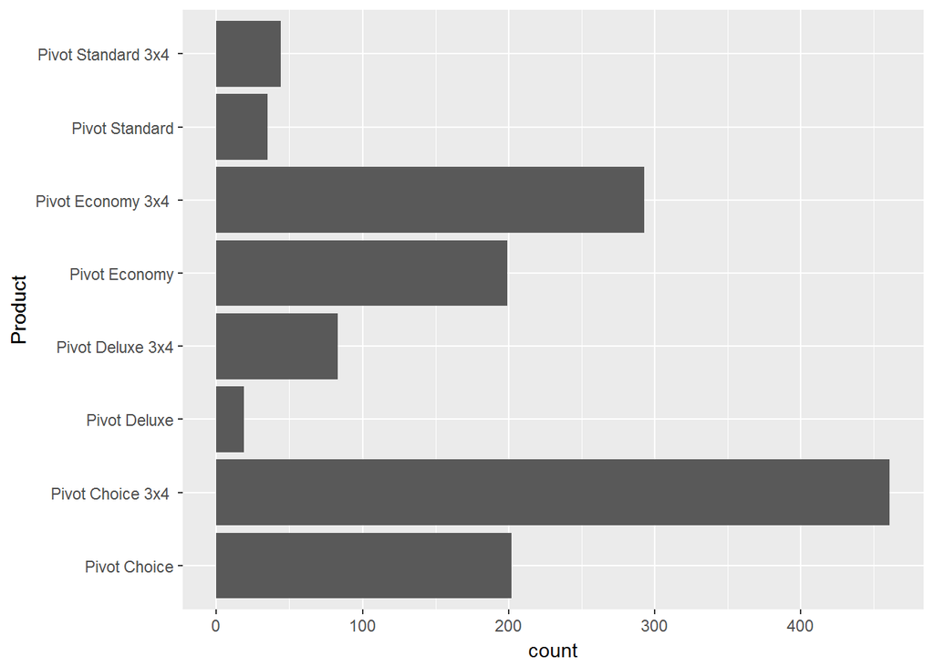

```r
ggplot(sales, aes(Product)) + geom_bar() + coord_flip()
```

### Number of sales by benefit

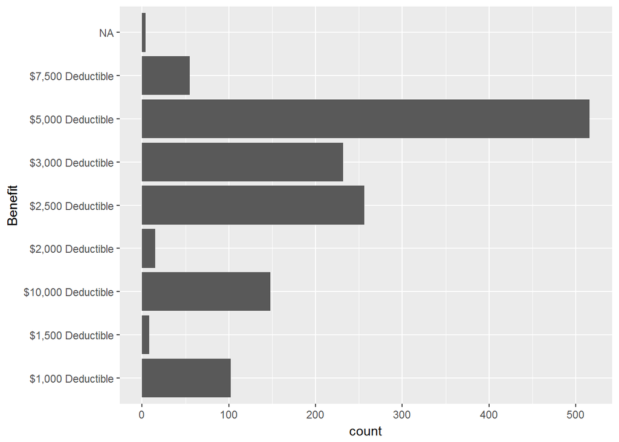

```r
ggplot(sales, aes(Benefit)) + geom_bar() + coord_flip()
```

### **STM Web Sales data - Jan-Jun 2017**

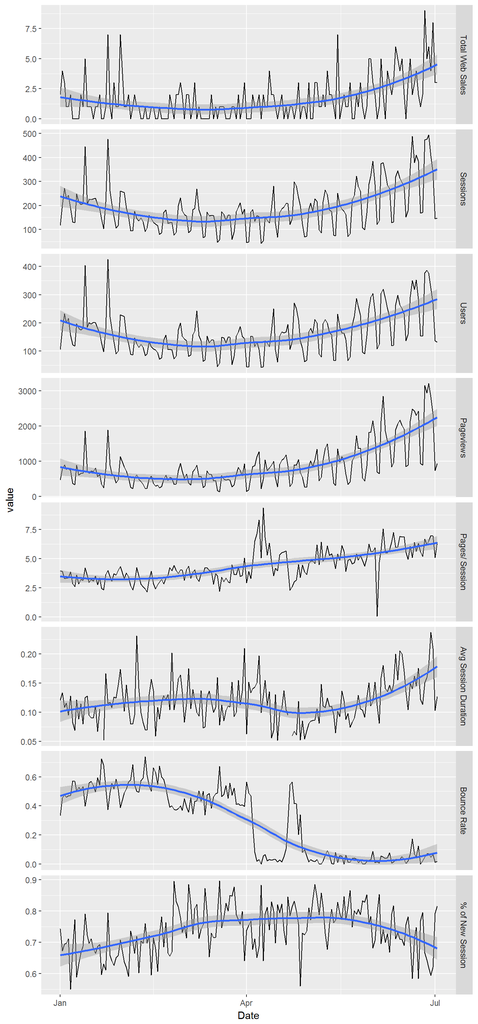

```r
melted_website <- melt(website, id.vars = "Date")

melted_website %>%
  filter(Date != "2017-01-31") %>%
  ggplot(aes(x=Date, y=value)) + geom_line() + geom_smooth() + facet_grid(variable~., scales = "free_y")
```

### Web Sales Y variable scatter plots

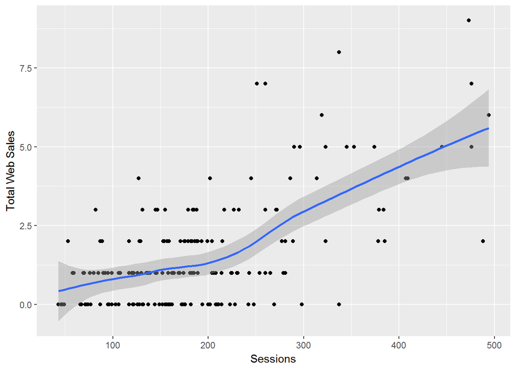

```r
website %>%
  filter(Date != "2017-01-31") %>%
  ggplot(aes(Sessions, `Total Web Sales`)) + geom_point() + geom_smooth()
```

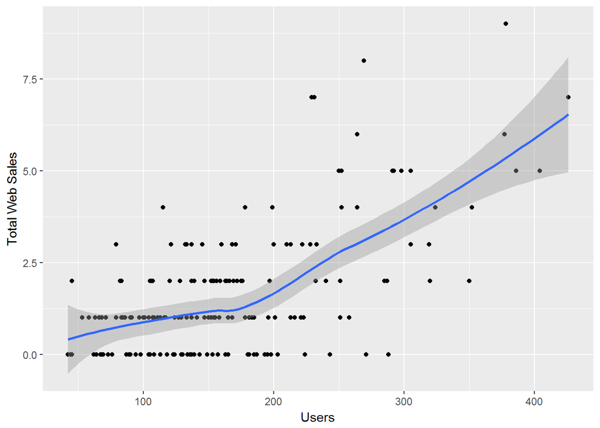

```r
website %>%
  filter(Date != "2017-01-31") %>%
  ggplot(aes(Users, `Total Web Sales`)) + geom_point() + geom_smooth()
```

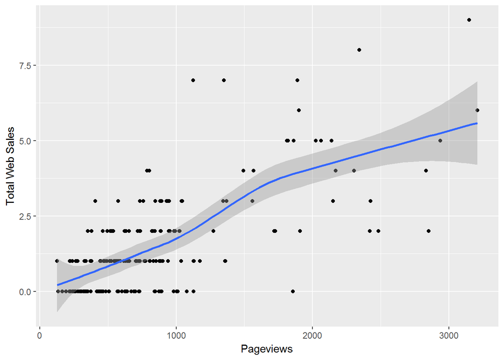

```r
website %>%
  filter(Date != "2017-01-31") %>%
  ggplot(aes(Pageviews, `Total Web Sales`)) + geom_point() + geom_smooth()#
```

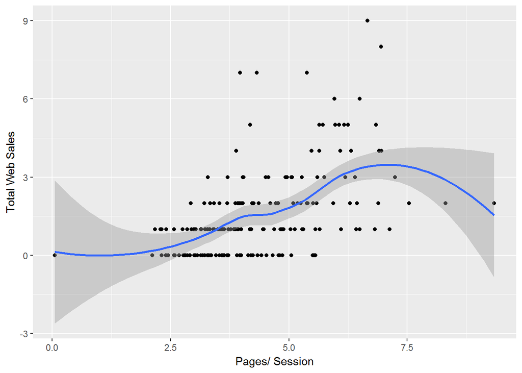

```r
website %>%
  filter(Date != "2017-01-31") %>%
  ggplot(aes(`Pages/ Session`, `Total Web Sales`)) + geom_point() + geom_smooth()
```

## Sales by state

```r
sales$State %>% table %>% sort(decreasing=T) %>% data.frame
```

```
##     . Freq
## 1  TX  244
## 2  GA  112
## 3  PA   97
## 4  AZ   92
## 5  IL   86
## 6  OH   84
## 7  VA   81
## 8  FL   80
## 9  MI   71
## 10 WI   69
## 11 TN   62
## 12 AL   48
## 13 NE   36
## 14 KY   31
## 15 AR   23
## 16 OK   22
## 17 DE   19
## 18 IA   18
## 19 WV   17
## 20 MS   16
## 21 IN   11
## 22 WY    8
## 23 DC    5
## 24 SD    2
## 25 ID    1
## 26 MD    1
```

## Inactive accounts

This could be an area where we provide more value than just reporting. Maybe some of these inactivities/cancellations can be controlled/reduced?

These columns **Date Inactive** and **Inactive Reason** are usually both filled out together

```r
table(is.na(sales$`Date Inactive`) == is.na(sales$`Inactive Reason`))
```

```
##
## FALSE  TRUE
##    36  1300
```

### Top reasons for account inactivity

```r
table(sales$`Inactive Reason`) %>% sort(decreasing=T) %>% data.frame %>% head(10)
```

```
##                         Var1 Freq
## 1               Changed Mind  111
## 2  Dissatisfied with Product   56
## 3             Not Interested   34
## 4      Policy Term Exhausted   29
## 5     Cannot use the product   27
## 6    Received Group Coverage   26
## 7     Replacing with A1 Plan   21
## 8               Can't Afford   19
## 9     Received Major Medical   15
## 10                Chargeback   13
```

# **Candidate graphs for reporting**

This section contains graphs they can potentially be interested in based on the other sheets they created in the Excel file.

- Sales by state
- Sales by month
- Sales by product
- Monthly, daily sales

## Sales ($) by month

**The data is from 12/2016 - 07/2017**

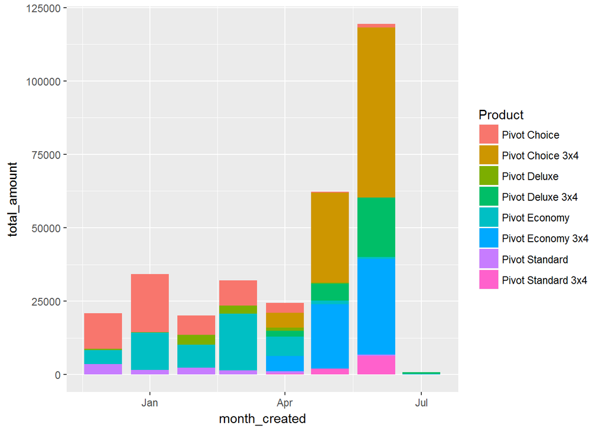

```r
sales %>%
  group_by(month_created, Product) %>%
  summarise(total_amount = sum(Amount, na.rm = T)) %>%
  ggplot(aes(x=month_created, y=total_amount, fill=Product)) + geom_bar(stat="identity")
```

## Sales ($) by week (more granular)

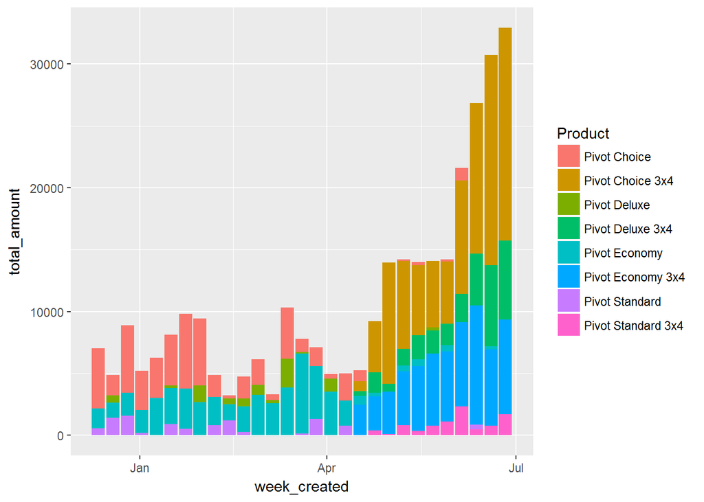

```r
sales %>%
  group_by(week_created, Product) %>%
  summarise(total_amount = sum(Amount, na.rm = T)) %>%
  ggplot(aes(x=week_created, y=total_amount, fill=Product)) + geom_bar(stat="identity")
```

## Number of sales/accounts by week

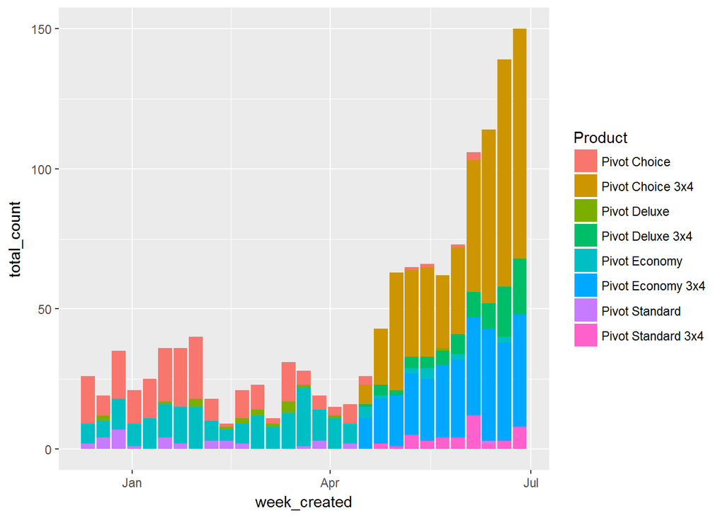

```r
sales %>%
  group_by(week_created, Product) %>%
  summarise(total_count = sum(Count, na.rm = T)) %>%
  ggplot(aes(x=week_created, y=total_count, fill=Product)) + geom_bar(stat="identity")
```

## Sales ($) by state for June (not working yet)

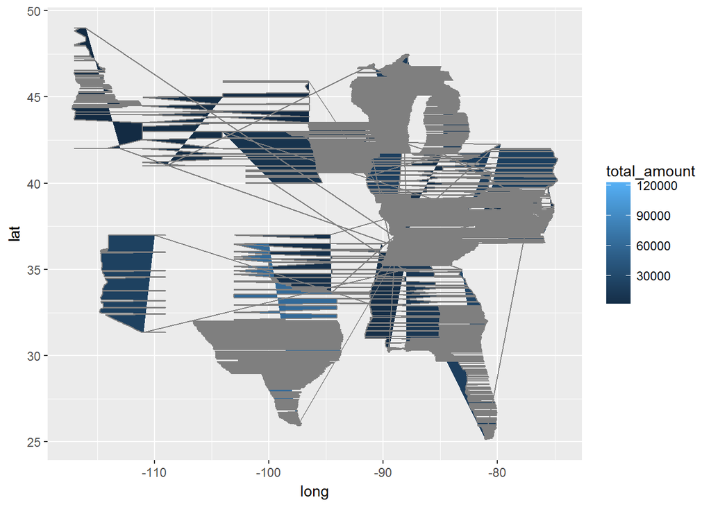

```r
st <- state_sales %>%
  group_by(region, lat, long, group) %>%
  summarise(total_amount = sum(Amount, na.rm = T))

ggplot(st, aes(long, lat)) + geom_polygon(aes(group=group, fill=total_amount)) +
  geom_path(colour="grey50")
```

## States as a proportion of TOTAL sales/accounts over time

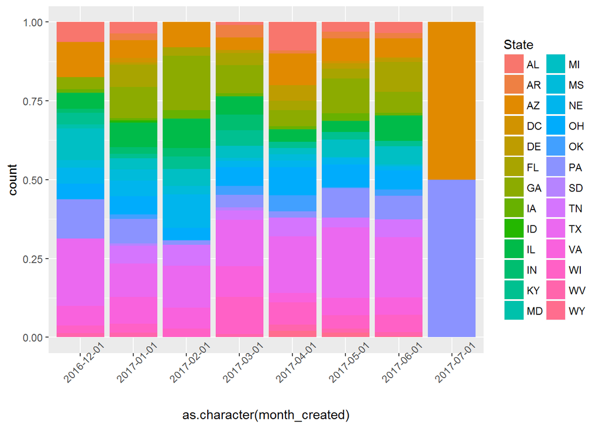

```r
ggplot(sales) + geom_bar(mapping=aes(as.character(month_created), fill = State), position = "fill") + theme(axis.text.x = element_text(angle = 45))
```

# Notes, impressions

## Source information

There appear to be **3 main sources** of data that are in the combined sales summary

```r
# get sheet names from excel file
readxl::excel_sheets("2017 Sales Summary.xlsx")
```

```
## [1] "Adroit Sales Summary"   "Asst Agencies"
## [3] "STM Web Sales Summary"  "Combined Sales Summary"
## [5] "One Page Summary"       "Raw Data From Adroit"
## [7] "Latitude Sales"         "States"
## [9] "Prem by Source"
```

These 3 sources are **Adroit Sales Summary**, **Asst Agencies**, and **STM Web Sales Summary**. They get added together to calculate totals in the **Combined Sales Summary** sheet. I initially thought that the **Raw Data From Adroit** sheet populated the 3 main sources but some simple checking has shown me that the numbers are off - Specifically i found that there are less entries for plans in Texas in the raw data (244) compared to the combined sales summary (300).

### Web data outlier on 1/31/2017

Removed Web data outlier on 1/31/2017 to better see overall trend of web sales indicators.

Here are the graphs with the outlier put back

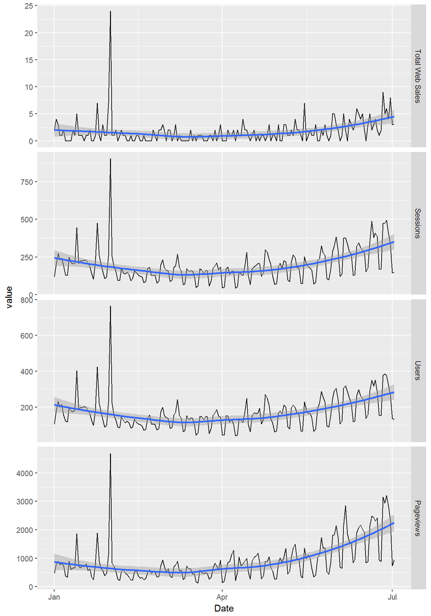

```r
melted_website %>%
  filter(variable %in% c("Date","Total Web Sales", "Sessions","Users","Pageviews")) %>%
  ggplot(aes(x=Date, y=value)) + geom_line() + geom_smooth() + facet_grid(variable~., scales = "free_y")
```